# Alcohol vs Seat choice

Daniel Barraza

Fall 2026

Our Goal is to answer this question Is there a difference between the alcohol consumed between the row you choose to sit in??

# introduction

the question is this; is there a relationship between where you sit in class and how much you drink?  
data from UCDavis math 116 class  
$H_O$ there is no relationship between what row in class you sit and how much you drink.  
$H_A$ there is a difference between what row you sit in class and how much you drink.

# Methods

seat is categorical  
alcohol is numerical

# data summaries

## Now add in boxplot

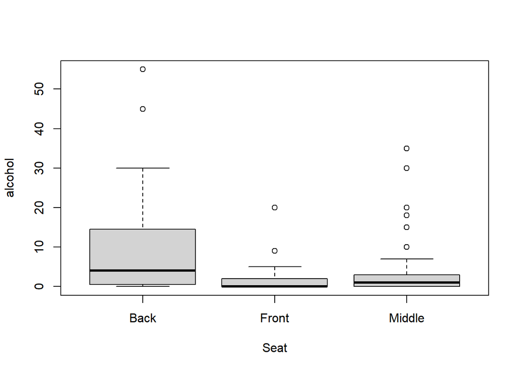

```r
boxplot(alcohol~Seat,data=davisdata)
```

Graph demonstrates that if the students sits in the back they are more ounces per week of alcohol than the students who sit in the front or middle.

## Numerical Summaries

```r
favstats(alcohol~Seat,data=davisdata)
```

```
##     Seat min   Q1 median    Q3 max     mean        sd  n missing
## 1   Back   0 0.75      4 14.25  55 9.625000 12.963970 32       0
## 2  Front   0 0.00      0  2.00  20 1.803030  3.878908 33       0
## 3 Middle   0 0.00      1  3.00  35 3.283133  6.353025 83       0
```

## Inferential Tests

```r
model1 <- aov(alcohol~Seat,data=davisdata)
summary.aov(model1)
```

```
##              Df Sum Sq Mean Sq F value   Pr(>F)
## Seat          2   1199   599.4   9.656 0.000116 ***
## Residuals   145   9001    62.1
## ---
## Signif. codes:  0 '***' 0.001 '**' 0.01 '*' 0.05 '.' 0.1 ' ' 1
```

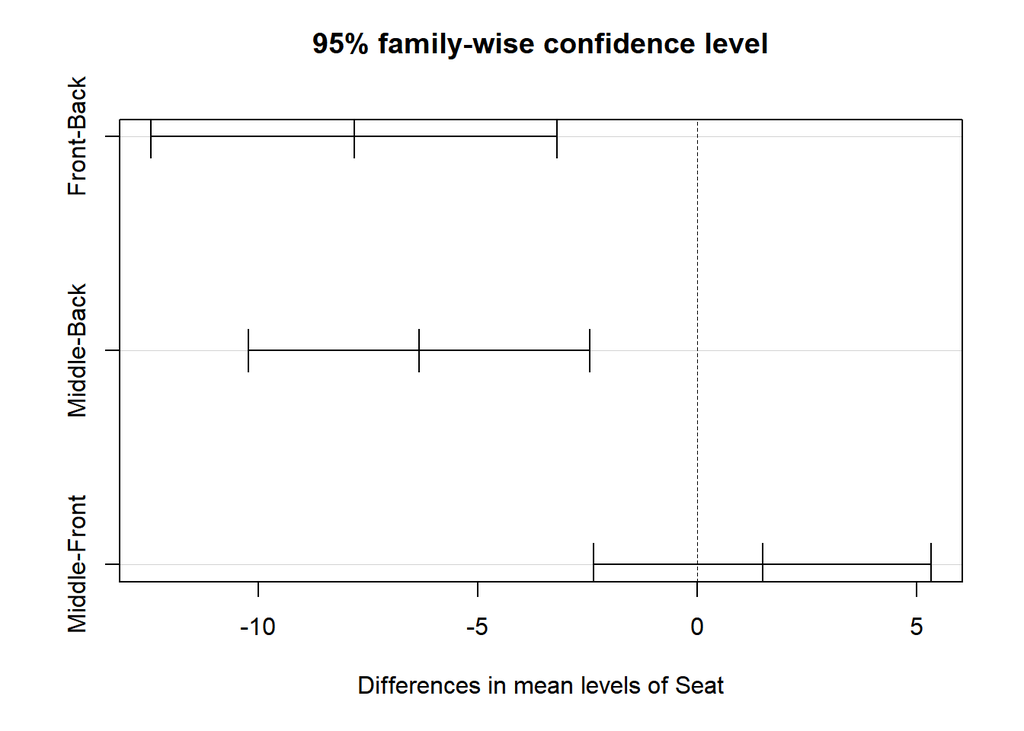

```r
plot(TukeyHSD(model1))
```

The tukey graph shows there is a difference in alcohol consumption between students who sit in the front and back and middle and back. there is no difference in alcohol consumption between the front and middle rows.

## Conclusion

Does the row of seats you sit have an impact on alcohol consumption?  
recorded data shows that students sitting in the back row consume a higher level of alcohol on average than students in the middle and front rows.  
We reject the null hypothesis that says that the row that you sit does not determine your alcohol consumption at all.